# **A Cornerstone in Structural Estimation: BLP's method**

### Alfred Galichon (NYU & Sciences Po) and Ugo Arena (Sciences Po)

## 'math+econ+code' masterclass series

#### With python code examples

© 2018-2026 by Alfred Galichon. Past and present support from NSF grant DMS-1716489, ERC grant CoG-866274 are acknowledged, as well as inputs from contributors listed [here](http://www.math-econ-code.org/team).

**If you reuse material from this masterclass, please cite as:**  
Alfred Galichon, 'math+econ+code' masterclass. https://github.com/math-econ-code/mec_notebooks

# **References**

Lin, Ranie. "Berry-Levinsohn-and-Pakes-1995-Replication." GitHub. https://github.com/ranielin/Berry-Levinsohn-and-Pakes-1995-Replication.

Galichon, Alfred. Discrete Choice Models: Mathematical Methods, Data Science, and Econometrics. Princeton Univeristy Press.

Galichon, Alfred. "math-econ-code." GitHub. https://github.com/math-econ-code.

Berry, Steven, James Levinsohn, and Ariel Pakes. "Automobile Prices in Market Equilibrium." Econometrica 63, no. 4 (1995): 841–90. https://doi.org/10.2307/2171802.

Conlon, Christopher and Jeff Gortmaker (2020). Best practices for differentiated products demand estimation with PyBLP. In: *The RAND Journal of Economics* 51.4, pp. 1108–1161.

The aim of this notebook is to replicate BLP's results, from Berry, Levinsohn, and Pakes, Automobile Prices in Market Equilibrium (1995)

```python
import pandas as pd, numpy as np
from scipy.optimize import minimize
import scipy, datetime
from sklearn.linear_model import LinearRegression
from scipy.linalg import block_diag
!pip install pyblp
import pyblp
!pip install mec
from mec.data import load_blp_car_data
from mec.blp import create_blp_instruments, organize_markets, collapse_markets,build_nus,build_dnudps
import pandas_datareader.data as web
import statsmodels.api as sm
from statsmodels.sandbox.regression.gmm import IV2SLS
pyblp.options.verbose = False
```

[output not shown]

# **Loading our Data**

```python
prod, _ = load_blp_car_data()
print(prod.head())
```

```
     name  car_ids  market_ids  cy  dr  at  ps  air  drv    prices  ...  \
0  AMGREM      129        1971   6   2   0   0    0   -9  4.935802  ...
1  AMHORN      130        1971   6   4   0   0    0   -9  5.516049  ...
2  AMJAVL      132        1971   6   2   0   0    0   -9  7.108642  ...
3  AMMATA      134        1971   6   4   0   0    0   -9  6.839506  ...
4  AMAMBS      136        1971   6   4   1   0    0   -9  8.928395  ...

   supply_instruments2  supply_instruments3  supply_instruments4  \
0                  0.0             1.705933             1.595656
1                  0.0             1.680910             1.490295
2                  0.0             1.801067             1.357703
3                  0.0             1.818061             1.261347
4                  0.0             1.933210             1.237365

   supply_instruments5  supply_instruments6  supply_instruments7  \
```

[output cut: 21 more lines]

```python
start = datetime.datetime(1971, 1, 1)
end = datetime.datetime(1990, 1, 1)

households_df = web.DataReader('TTLHH', 'fred', start, end)

households_df['Year'] = households_df.index.year
households_1000s = pd.Series(households_df.TTLHH.values, index=households_df.Year).to_dict()
```

# **Descriptive Statistics (Replication of Table I & II)**

**Description of the BLP dataset**

The original data on product characteristics were obtained from annual issues of the Automotive News Market Data Book. The included product characteristics are the number of cylinders, doors, weight, engine displacement, horsepower, length, width, wheelbase, MPG rating, and dummy variables for standard equipment such as air conditioning. The price used is the base model's list retail price in thousands of 1983 dollars. The sales variable corresponds to U.S. sales in thousands by nameplate, and the characteristics reflect the base model for a given nameplate.

The dataset contains **all models marketed from 1971 to 1990**, excluding models with insignificant market shares. The authors treat each model/year combination as an observation, yielding a **sample size of 2,217**. Two observations in adjacent years represent the same model if they meet two criteria: (i) they share the same nameplate, and (ii) their horsepower, width, length, and wheelbase do not change by more than 10%. This classification results in a total of **997 distinct models**.

In the dataset, a **car's price is endogenous** because it is correlated with unobserved characteristics ($\xi$). For example, a car might have a great reputation for reliability or a beautiful design that isn't captured by the data's basic metrics. If we don't correct for this, our price sensitivity estimate ($\alpha$) will be severely biased. To fix this, the authors constructed instruments directly from the dataset using the physical characteristics of the cars. The dataset constructs **three categories of instruments**:

- **Own Characteristics**: Physical traits of the car itself.
- **Same-Firm Characteristics** : The sum of the characteristics of all other cars produced by the same automaker in that market
- **Rival-Firm Characteristics (Market Competition)** : The sum of the characteristics of all cars produced by competing automakers in that market.

Additional data was gathered and transformed; for instance, miles per dollar (MP$) was calculated by dividing MPG by the real price of unleaded gasoline (sourced from Business Statistics). The market size ($M$) was defined as the number of US households in thousands, originally sourced from the Statistical Abstract of the US (though we draw this from FRED). Finally, we provide some **summary descriptive statistics** for the variables used below.

# **Table I** : Descriptive statistics

**Table I** provides a **year-by-year summary of the U.S. automobile market's overarching trends from 1971 to 1990**.

It displays the total number of distinct car models available each year alongside their average sales quantities and real prices.

Additionally, it tracks the evolution of sales-weighted vehicle characteristics, such as horsepower-to-weight ratio, size, and fuel efficiency.

Finally, it highlights the shifting competitive landscape by showing the market shares of Domestic, Japanese, and European manufacturers.

```python
if 'region' in prod.columns:
    region_str = prod['region'].astype(str).str.upper()
    prod['Domestic'] = region_str.str.contains('US').astype(int)
    prod['Japan']    = region_str.str.contains('JP').astype(int)
    prod['European'] = region_str.str.contains('EU').astype(int)

# We reconstruct Quantity (Sales in 1000s)
prod['market_size'] = prod['market_ids'].map(households_1000s)
prod['Quantity'] = prod['shares'] * prod['market_size']

# We define columns for the sales-weighted mean
cols_to_weight = ['prices', 'Domestic', 'Japan', 'European', 'hpwt', 'space', 'air', 'mpg', 'mpd']

def sales_weighted_mean(df, value_col):
    return np.average(df[value_col], weights=df['Quantity'])

# We build the table row by year
table_rows = []
years = sorted(prod['market_ids'].unique())

for year in years:
    group = prod[prod['market_ids'] == year]

    row = {
        'Year': str(year),
        'No. of Models': len(group),
        'Quantity': group['Quantity'].mean()
    }

    for col in cols_to_weight:
        row[col] = sales_weighted_mean(group, col)

    table_rows.append(row)

row_all = {
    'Year': 'All',
    'No. of Models': len(prod),
    'Quantity': prod['Quantity'].mean()
}
for col in cols_to_weight:
    row_all[col] = sales_weighted_mean(prod, col)

table_rows.append(row_all)
```

We format and display the table, which we compare with the table in the original paper.

```python
table_1_df = pd.DataFrame(table_rows)

rename_map = {
    'prices': 'Price',
    'hpwt': 'HP/Wt',
    'space': 'Size',
    'air': 'Air',
    'mpg': 'MPG',
    'mpd': 'MP$'
}
table_1_df.rename(columns=rename_map, inplace=True)

format_cols = [col for col in table_1_df.columns if col not in ['Year', 'No. of Models']]
formatters = {col: '{:.3f}'.format for col in format_cols}

pd.set_option('display.max_rows', None)

print("- Table I: Descriptive Statistics -")
print(table_1_df.to_string(formatters=formatters, index=False))
```

```
- Table I: Descriptive Statistics -
Year  No. of Models Quantity  Price Domestic Japan European HP/Wt  Size   Air   MPG   MP$
1971             92   84.418  7.868    0.866 0.057    0.077 0.490 1.496 0.000 1.662 1.849
1972             89   96.347  7.979    0.892 0.042    0.066 0.391 1.510 0.014 1.619 1.875
1973             86   90.650  7.535    0.932 0.040    0.028 0.364 1.529 0.022 1.589 1.818
1974             72  102.330  7.506    0.887 0.050    0.064 0.347 1.510 0.026 1.567 1.452
1975             93   82.742  7.821    0.853 0.083    0.064 0.337 1.479 0.054 1.584 1.503
1976             99   91.776  7.787    0.876 0.081    0.043 0.338 1.508 0.059 1.759 1.696
1977             95   95.300  7.651    0.837 0.112    0.051 0.340 1.467 0.032 1.947 1.835
1978             95   97.773  7.645    0.855 0.107    0.039 0.346 1.405 0.034 1.982 1.929
1979            102   79.212  7.599    0.803 0.158    0.038 0.348 1.343 0.047 2.061 1.657
1980            103   70.184  7.718    0.773 0.191    0.036 0.350 1.296 0.078 2.215 1.466
1981            116   61.170  8.349    0.741 0.213    0.046 0.349 1.286 0.094 2.363 1.559
1982            110   61.604  8.831    0.714 0.235    0.051 0.347 1.277 0.134 2.440 1.817
1983            115   66.786  8.821    0.734 0.215    0.051 0.351 1.276 0.126 2.601 2.087
1984            113   84.449  8.870    0.783 0.179    0.038 0.361 1.293 0.129 2.469 2.117
1985            136   76.669  8.938    0.761 0.191    0.048 0.372 1.265 0.140 2.261 2.024
1986            130   82.800  9.382    0.733 0.216    0.050 0.379 1.249 0.176 2.416 2.856
1987            143   66.446  9.965    0.702 0.245    0.052 0.395 1.246 0.229 2.327 2.789
1988            150   65.845 10.069    0.717 0.237    0.045 0.396 1.251 0.237 2.334 2.919
1989            147   62.565 10.321    0.690 0.261    0.049 0.406 1.259 0.289 2.310 2.806
1990            131   65.698 10.337    0.682 0.276    0.043 0.419 1.270 0.308 2.270 2.852
 All           2217   77.314  8.609    0.789 0.162    0.049 0.372 1.356 0.116 2.100 2.088
```

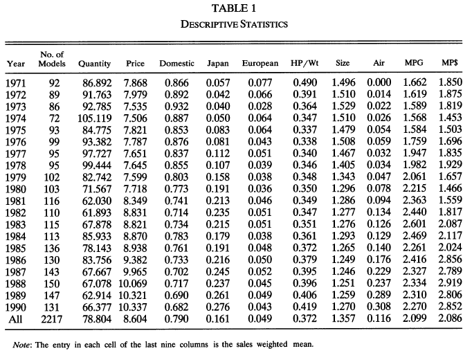

# **Table II** : The range of continuous demand characteristics

**Table II** illustrates the overall distribution and spread of the continuous variables used to model consumer demand.

It reports the **minimum** (0th), **25th percentile**, **median** (50th), **75th percentile**, and **maximum** (100th) values for each characteristic.

These variables include critical decision factors like price, total sales volume, physical vehicle size, and miles per dollar.

The table identifies the specific car models that represent the absolute minimum and maximum extremes.

```python
# We define variables matching Table II
continuous_vars = ['prices', 'Quantity', 'hpwt', 'space', 'mpg', 'mpd']

# The paper reports the 0th (Min), 25th, 50th, 75th, and 100th (Max) percentiles, we will do the same
quantiles = [0.0, 0.25, 0.50, 0.75, 1.0]

# We calculate the quantiles for each variable
table_2_data = {}
for var in continuous_vars:
    table_2_data[var] = prod[var].quantile(quantiles).values

# We create the DataFrame and transpose it so Variables are rows
table_2_df = pd.DataFrame(table_2_data, index=['0', '25', '50', '75', '100']).T

# We rename the index to match the exact Variable names in the paper
rename_map = {
    'prices': 'Price',
    'Quantity': 'Sales',
    'hpwt': 'HP/Wt',
    'space': 'Size',
    'mpg': 'MPG',
    'mpd': 'MP$'
}
table_2_df.rename(index=rename_map, inplace=True)

for col in table_2_df.columns:
    table_2_df[col] = table_2_df[col].apply(lambda x: f"{float(x):.3f}")

# We dynamically append car names for the Min (0) and Max (100) percentiles
if 'name' in prod.columns:
    for var, row_name in zip(continuous_vars, table_2_df.index):
        # Find the index of the min and max values
        min_idx = prod[var].idxmin()
        max_idx = prod[var].idxmax()

        min_name = prod.loc[min_idx, 'name']
        min_year = str(prod.loc[min_idx, 'market_ids'])[-2:]

        max_name = prod.loc[max_idx, 'name']
        max_year = str(prod.loc[max_idx, 'market_ids'])[-2:]

        table_2_df.at[row_name, '0'] += f" ('{min_year} {min_name})"
        table_2_df.at[row_name, '100'] += f" ('{max_year} {max_name})"

print("- TABLE II -")
print("THE RANGE OF CONTINUOUS DEMAND CHARACTERISTICS\n")
print(table_2_df.to_string(justify='left'))
```

```
- TABLE II -
THE RANGE OF CONTINUOUS DEMAND CHARACTERISTICS

      0                   25      50      75       100
Price  3.393 ('90 YGGVPL)   6.714   8.729   13.074   68.597 ('89 PS911C)
Sales  0.048 ('73 TY1600)  15.161  46.533  107.839  631.606 ('72 BKRIVE)
HP/Wt  0.170 ('80 PLGRNF)   0.337   0.375    0.428    0.948 ('89 PS911T)
Size   0.756 ('73 HDCIVI)   1.131   1.270    1.453    1.888 ('72 IMLEBA)
MPG    0.913 ('74 CDELDR)   1.700   2.000    2.500    5.300 ('89 GEOMET)
MP$    0.846 ('74 CDELDR)   1.557   2.010    2.483    6.437 ('89 GEOMET)
```

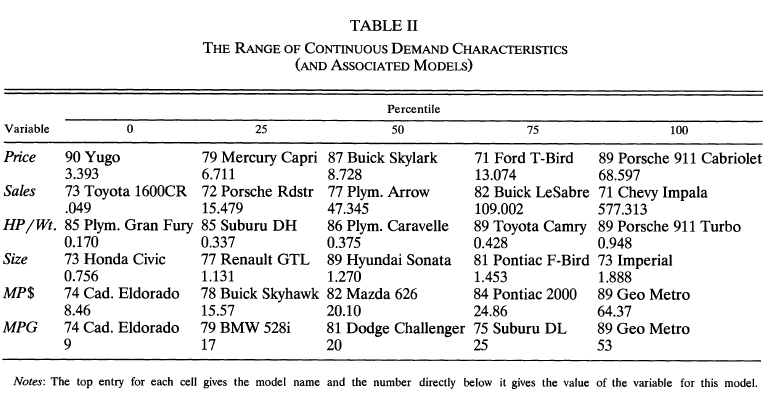

# **The Logit and the IV Logit**

# **Table III** : Results with Logit Demand and Marginal Cost Pricing

This initial set of results is based on the simplest logit utility specification. This model is estimated via OLS by regressing the difference in log-market shares, $\ln(s_j) - \ln(s_0)$, on product characteristics and price.

Although one could argue for a more extensive set of attributes, the authors adopt a concise list for the sake of comparability.A key feature of this specification is the treatment of unobserved product attributes ($\xi_j$). The model's error term explicitly accounts for characteristics that are observed by consumers and influence their purchasing decisions but remain unobserved by the econometrician.

```python
# We Prepare Dependent Variables
# Logit Demand Dependent Variable: ln(s_j) - ln(s_0)
prod['sum_shares'] = prod.groupby('market_ids')['shares'].transform('sum')
prod['s_0'] = 1 - prod['sum_shares']
prod['y_demand'] = np.log(prod['shares']) - np.log(prod['s_0'])

# Cost Function Dependent Variable: ln(price)
prod['y_supply'] = np.log(prod['prices'])

# We prepare Independent Variables
prod['const'] = 1
# Trend in BLP is in our case the two digits of the year
prod['trend'] = prod['market_ids'] - 1900

# We apply log transformations for the cost function covariates
prod['ln_hpwt'] = np.log(prod['hpwt'])
prod['ln_space'] = np.log(prod['space'])
prod['ln_mpg'] = np.log(prod['mpg'])

# We define covariate columns exactly as they appear in Table III
dem_cols = ['const', 'hpwt', 'air', 'mpd', 'space', 'prices']
sup_cols = ['const', 'ln_hpwt', 'air', 'ln_mpg', 'ln_space', 'trend']

X_dem = prod[dem_cols].values
y_dem = prod['y_demand'].values

X_sup = prod[sup_cols].values
y_sup = prod['y_supply'].values

# We prepare Instruments for IV
dem_inst_cols = [c for c in prod.columns if c.startswith('demand_instruments')]
sup_inst_cols = [c for c in prod.columns if c.startswith('supply_instruments')]

if len(dem_inst_cols) > 0 and len(sup_inst_cols) > 0:
    Z_dem_cols = ['const', 'hpwt', 'air', 'mpd', 'space'] + dem_inst_cols
    Z_sup_cols = ['const', 'ln_hpwt', 'air', 'ln_mpg', 'ln_space', 'trend'] + sup_inst_cols

    Z_dem = prod[Z_dem_cols].values
    Z_sup = prod[Z_sup_cols].values
else:
    def build_blp_instruments(df, X_cols):
        firm_sums, market_sums = [], []
        for m in df['market_ids'].unique():
            market_df = df[df['market_ids'] == m]
            for f in market_df['firm_ids'].unique():
                firm_df = market_df[market_df['firm_ids'] == f]
                firm_sums.append(firm_df[X_cols].sum() - firm_df[X_cols])

                other_firm_df = market_df[market_df['firm_ids'] != f]
                market_sums.append(pd.DataFrame([other_firm_df[X_cols].sum()] * len(firm_df), index=firm_df.index))
        return np.hstack([df[X_cols].values, pd.concat(firm_sums).sort_index().values, pd.concat(market_sums).sort_index().values])

    Z_dem = build_blp_instruments(prod, ['const', 'hpwt', 'air', 'mpd', 'space'])
    Z_sup = build_blp_instruments(prod, ['const', 'ln_hpwt', 'air', 'ln_mpg', 'ln_space', 'trend'])
```

Next, estimate paramters using `Statsmodels`.

```python
# Demand (OLS)
res_dem_ols = sm.OLS(y_dem, X_dem).fit()
beta_dem_ols, se_dem_ols = res_dem_ols.params, res_dem_ols.bse
r2_dem_ols = res_dem_ols.rsquared

# Demand (IV/2SLS)
res_dem_iv = IV2SLS(endog=y_dem, exog=X_dem, instrument=Z_dem).fit()
beta_dem_iv, se_dem_iv = res_dem_iv.params, res_dem_iv.bse

# Supply / Marginal Cost (OLS)
res_sup_ols = sm.OLS(y_sup, X_sup).fit()
beta_sup_ols, se_sup_ols = res_sup_ols.params, res_sup_ols.bse
r2_sup_ols = res_sup_ols.rsquared

# ==
# We format and display Table III
# ==

param_names = ['Constant', 'HP/Weight', 'Air', 'MP$', 'Size', 'Price',
               'ln(HP/Weight)', 'ln(MPG)', 'ln(Size)', 'Trend']

table_3 = pd.DataFrame(index=param_names, columns=['Demand (OLS)', 'Demand (IV)', 'ln(MC) (OLS)'])
table_3.fillna('', inplace=True)

def fmt(b, s):
    return f"{b:8.3f}\n({s:6.3f})"

for i, var in enumerate(['Constant', 'HP/Weight', 'Air', 'MP$', 'Size', 'Price']):
    table_3.at[var, 'Demand (OLS)'] = fmt(beta_dem_ols[i], se_dem_ols[i])
    table_3.at[var, 'Demand (IV)']  = fmt(beta_dem_iv[i], se_dem_iv[i])

for i, var in enumerate(['Constant', 'ln(HP/Weight)', 'Air', 'ln(MPG)', 'ln(Size)', 'Trend']):
    table_3.at[var, 'ln(MC) (OLS)'] = fmt(beta_sup_ols[i], se_sup_ols[i])

print(f"R^2 for Demand (OLS): {r2_dem_ols:.4f}")
print(f"R^2 for ln(Price) (OLS): {r2_sup_ols:.4f}\n")

print("--- TABLE III ---")
print("RESULTS WITH LOGIT DEMAND AND MARGINAL COST PRICING")
print(table_3)
```

```
R^2 for Demand (OLS): 0.3871
R^2 for ln(Price) (OLS): 0.6564

--- TABLE III ---
RESULTS WITH LOGIT DEMAND AND MARGINAL COST PRICING
                     Demand (OLS)         Demand (IV)        ln(MC) (OLS)
Constant        -10.072\n( 0.253)    -9.921\n( 0.262)     1.882\n( 0.119)
HP/Weight        -0.124\n( 0.277)     1.179\n( 0.403)
Air              -0.034\n( 0.073)     0.468\n( 0.133)     0.680\n( 0.019)
MP$               0.265\n( 0.043)     0.175\n( 0.049)
Size              2.342\n( 0.125)     2.293\n( 0.129)
Price            -0.089\n( 0.004)    -0.134\n( 0.011)
ln(HP/Weight)                                             0.520\n( 0.035)
ln(MPG)                                                  -0.471\n( 0.049)
ln(Size)                                                  0.125\n( 0.063)
Trend                                                     0.013\n( 0.002)
```

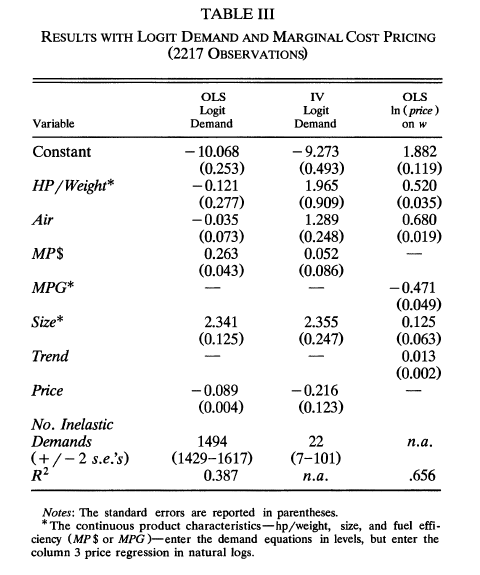

## **The Demand Side: OLS vs. IV**

In the **Demand (OLS)** column, the **model produces counterintuitive results**. The coefficient on Price is relatively small (-0.089). Worse, the coefficients for desirable attributes like HP/Weight (-0.124) and Air Conditioning (-0.034) are negative, falsely implying that consumers dislike those attributes. It is caused by an endogeneity problem. OLS cannot account for unobserved quality (like brand prestige, ride smoothness, or aesthetic design), biasing price towards zero and distorting attributes.

The **Demand (IV)** column uses instruments to isolate the variation in price that is strictly due to market competition, uncorrelated from unobserved quality. Once corrected, the **Price coefficient becomes much more negative** (-0.134), showing that consumers are correctly identified as being more price-sensitive. Furthermore, the coefficients for HP/Weight (1.179) and Air (0.468) flip to their expected positive signs, confirming that consumers do indeed value characteristics.

## **The Supply Side (Marginal Cost)**

The **ln(MC) (OLS)** column represents a basic cost function.

The positive coefficients for HP/Weight (0.520), Air (0.680), and Size (0.125) make perfect economic sense: it costs manufacturers more money to build larger, heavier, more powerful, and better-equipped vehicles.

If we do not properly instrument for price, the demand model will generate biased consumer preferences and unrealistic substitution patterns.

# **Results from the Full Model**

# **Table IV** : Estimated Parameters of the Demand and Pricing Equations

**Table IV** presents the **core structural parameter estimates** from the full random coefficients logit model, covering both consumer demand and firm pricing equations.

The demand side reports the **mean consumer preferences** ($\beta$) for vehicle attributes alongside the **standard deviations** ($\sigma$) that capture unobserved consumer heterogeneity.

It also highlights the **crucial price coefficient** ($\alpha$), which interacts with consumer income to reflect realistic, income-based price sensitivities.

Finally, the supply side details the **marginal cost parameters** ($\gamma$), showing how features like vehicle size, air conditioning, and horsepower directly impact manufacturing costs.

Following the recommendations of Conlon and Gortmaker (2020), we manually construct the agent data using 2,000 Halton draws via PyBLP’s built-in tools.

```python
# Get the Halton nodes from PyBLP
base_integration = pyblp.build_integration(
    integration=pyblp.Integration('halton', size=2000),
    dimensions=6
)

agent_dict = {
    'weights': base_integration['weights'].flatten()
}

for i in range(6):
    agent_dict[f'nodes{i}'] = base_integration['nodes'][:, i].flatten()

base_df = pd.DataFrame(agent_dict)

# Historical log-income means (approximate CPS data for 1971-1990)
D_mean = {
    1971: 2.01156, 1972: 2.06526, 1973: 2.07843, 1974: 2.05775,
    1975: 2.02915, 1976: 2.05346, 1977: 2.06745, 1978: 2.09805,
    1979: 2.10404, 1980: 2.07208, 1981: 2.06019, 1982: 2.06561,
    1983: 2.07672, 1984: 2.10437, 1985: 2.12608, 1986: 2.16426,
    1987: 2.18071, 1988: 2.18856, 1989: 2.21250, 1990: 2.18377
}
D_var = 2.9584

agent_frames = []
np.random.seed(123)

for t in prod['market_ids'].unique():
    market_agents = base_df.copy()
    market_agents['market_ids'] = t

    log_y = np.random.normal(loc=D_mean[int(t)], scale=np.sqrt(D_var), size=len(market_agents))
    market_agents['income'] = np.exp(log_y)

    agent_frames.append(market_agents)

final_agent_data = pd.concat(agent_frames, ignore_index=True)
```

To calculate the predicted market shares in the model, we cannot simply look at the "average" consumer. Instead, the model requires us to simulate a diverse population of consumers for every market and calculate each simulated person's probability of buying each car.

`nodes` (**Unobserved Heterogeneity**): These represent a consumer's hidden, personal tastes for vehicle characteristics. We need one node column for every random coefficient in your model. The original authors simply used a random number generator to pull 200 random points from a normal distribution, but we're following Conlon and Gortmaker and use Halton Draws to avoid simulation errors.

`income` : We draw random samples from a log-normal distribution that exactly matches the CPS mean and variance for that specific year.

```python
pyblp.options.weights_tol = 1e-3
pyblp.options.verbose = False

if 'trend' not in prod.columns:
    prod['trend'] = prod['market_ids'] - 1900

# We define Structural Formulations matching BLP (1995)
X1_formulation = pyblp.Formulation('1 + hpwt + air + mpd + space')
X2_formulation = pyblp.Formulation('1 + prices + hpwt + air + mpd + space')
X3_formulation = pyblp.Formulation('1 + log(hpwt) + air + log(mpg) + log(space) + trend')

product_formulations = (X1_formulation, X2_formulation, X3_formulation)
agent_formulation = pyblp.Formulation('0 + I(1 / income)')

# We initialize the PyBLP Problem
problem = pyblp.Problem(
    product_formulations=product_formulations,
    product_data=prod,
    agent_formulation=agent_formulation,
    agent_data=final_agent_data,
    costs_type='log'
)

# We set Starting Values (from original paper Table IV)
initial_sigma = np.diag([3.612, 0.0, 4.628, 1.818, 1.050, 2.056])
pi_start = np.zeros((6, 1))
pi_start[1, 0] = -43.501 # Price interacts with 1/income

sigma_lb = np.zeros_like(initial_sigma)
sigma_ub = np.full_like(initial_sigma, np.inf)
sigma_lb[1, 1] = 0.0
sigma_ub[1, 1] = 0.0

# We solve using 2-Step GMM and L-BFGS-B Optimizer
optimization = pyblp.Optimization('l-bfgs-b', {'gtol': 1e-3})

results = problem.solve(
    sigma=initial_sigma,
    pi=pi_start,
    sigma_bounds=(sigma_lb, sigma_ub),
    optimization=optimization,
    method='2s',
    initial_update = True,
    W_type = 'clustered',
    se_type = 'clustered'
)
```

We now formating and print Table IV.

```python
# Extract linear parameters
betas = results.beta.flatten()
beta_se = results.beta_se.flatten()
gammas = results.gamma.flatten()
gamma_se = results.gamma_se.flatten()

# Extract non-linear standard deviations
sigmas = np.diag(results.sigma)
sigma_se = np.diag(results.sigma_se)

# Extract price demographic interaction
alpha = results.pi[1, 0]
alpha_se = results.pi_se[1, 0]

demand_vars = ['Constant', 'HP/Weight', 'Air', 'MP$', 'Size']
supply_vars = ['Constant', 'ln(HP/Weight)', 'Air', 'ln(MPG)', 'ln(Size)', 'Trend']

sigma_mapped = [sigmas[0], sigmas[2], sigmas[3], sigmas[4], sigmas[5]]
sigma_se_mapped = [sigma_se[0], sigma_se[2], sigma_se[3], sigma_se[4], sigma_se[5]]

def fmt(est, se):
    return f"{est:8.3f}\n({se:6.3f})"

print("\n" + "="*2)
print("TABLE IV: ESTIMATED PARAMETERS OF THE DEMAND AND PRICING EQUATIONS")
print("="*2)

# --- DEMAND EQUATION ---
demand_df = pd.DataFrame(index=demand_vars, columns=['Means (Beta)', 'Std. Dev. (Sigma)'])
for i, var in enumerate(demand_vars):
    demand_df.at[var, 'Means (Beta)'] = fmt(betas[i], beta_se[i])
    demand_df.at[var, 'Std. Dev. (Sigma)'] = fmt(sigma_mapped[i], sigma_se_mapped[i])

print("\n--- DEMAND EQUATION ---")
print(demand_df.to_string())

# --- TERM ON PRICE ---
print("\n--- TERM ON PRICE ---")
price_df = pd.DataFrame(index=['Price (Alpha)'], columns=['Estimate (Pi)'])
price_df.at['Price (Alpha)', 'Estimate (Pi)'] = fmt(alpha, alpha_se)
print(price_df.to_string(header=False))

# --- PRICING (SUPPLY) EQUATION ---
supply_df = pd.DataFrame(index=supply_vars, columns=['Estimate (Gamma)'])
for i, var in enumerate(supply_vars):
    supply_df.at[var, 'Estimate (Gamma)'] = fmt(gammas[i], gamma_se[i])

print("\n--- PRICING (SUPPLY) EQUATION ---")
print(supply_df.to_string())
print("="*2)
```

```
==
TABLE IV: ESTIMATED PARAMETERS OF THE DEMAND AND PRICING EQUATIONS
==

--- DEMAND EQUATION ---
                 Means (Beta)   Std. Dev. (Sigma)
Constant     -5.577\n( 1.479)     3.750\n( 1.734)
HP/Weight     7.615\n( 1.857)     1.468\n( 6.998)
Air          -4.073\n( 1.817)     7.270\n( 1.641)
MP$           0.058\n( 0.515)     0.183\n( 1.542)
Size          2.945\n( 1.625)     4.595\n( 1.932)

--- TERM ON PRICE ---
Price (Alpha)   -62.852\n(11.689)

--- PRICING (SUPPLY) EQUATION ---
                 Estimate (Gamma)
Constant          1.261\n( 0.138)
ln(HP/Weight)     0.744\n( 0.063)
Air               0.602\n( 0.035)
ln(MPG)          -0.259\n( 0.063)
ln(Size)          0.128\n( 0.136)
Trend             0.017\n( 0.002)
==
```

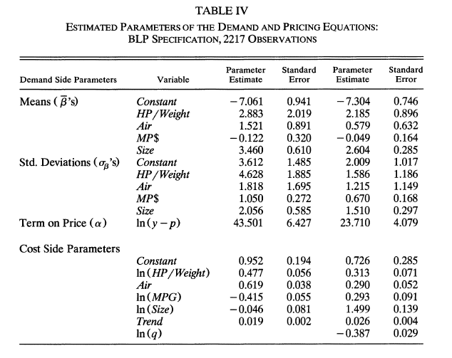

This table is the structural "engine" of the paper. It displays the raw mathematical coefficients estimated by the **GMM algorithm**:

**Demand Equation**: Shows the average consumer's baseline preference for a feature ($\beta$), and how much individual consumers vary in that preference ($\sigma$).

**Term on Price**: Shows the critical price sensitivity coefficient ($\alpha$). Because it is interacted with consumer income ($1/y$), it ensures that wealthier consumers are less sensitive to high car prices than lower-income consumers.

**Pricing (Supply) Equation**: Shows the parameters ($\gamma$) for how much each physical characteristic (like horsepower or size) adds to the underlying manufacturing marginal cost of the vehicle.

# **Table V**

**Table V** translates the parameter estimates from Table IV into practical, interpretable economic metrics by displaying **estimated demand elasticities**.

It focuses specifically on a representative sample of individual car models from the 1990 market.bFor each featured vehicle, the table lists its actual physical attributes and base price in the top row.

Directly beneath those values, the **own-elasticities** reveal exactly how sensitive that specific car's market share is to a hypothetical change in its own price or characteristics.

```python
# We compute Own-Elasticities using PyBLP for Table V attributes
prod['elas_hpwt']   = results.extract_diagonals(results.compute_elasticities(name='hpwt'))
prod['elas_air']    = results.extract_diagonals(results.compute_elasticities(name='air'))
prod['elas_mpd']    = results.extract_diagonals(results.compute_elasticities(name='mpd'))
prod['elas_space']  = results.extract_diagonals(results.compute_elasticities(name='space'))
prod['elas_prices'] = results.extract_diagonals(results.compute_elasticities(name='prices'))
prod['elas_prices'] = prod['elas_prices'].abs()

# We filter strictly for the year 1990
df_1990 = prod[prod['market_ids'] == 1990].copy()

target_cars = ['323', 'SENT', 'ESCO', 'CAVA', 'ACCO', 'TAUR', 'MAXI', 'SEVI', 'LS40', '735']

selected_rows = []
for car in target_cars:
    match = df_1990[df_1990['name'].str.contains(car, case=False, na=False)]
    if not match.empty:
        selected_rows.append(match.iloc[0])

sample_cars = pd.DataFrame(selected_rows)

# We format and Print the Replica of Table V
print("="*2)
print("TABLE V: A SAMPLE FROM 1990 OF ESTIMATED DEMAND ELASTICITIES")
print("="*2)

for _, row in sample_cars.iterrows():
    print(f"{row['name']:<10} {row['hpwt']:>10.3f} {row['air']:>10.3f} {row['mpd']:>10.3f} {row['space']:>10.3f} {row['prices']:>10.3f}")

    print(f"{'':<10} ({row['elas_hpwt']:>8.3f}) ({row['elas_air']:>8.3f}) ({row['elas_mpd']:>8.3f}) ({row['elas_space']:>8.3f}) ({row['elas_prices']:>8.3f})\n")

print("="*2)
```

```
==
TABLE V: A SAMPLE FROM 1990 OF ESTIMATED DEMAND ELASTICITIES
==
MZ323           0.366      0.000      3.645      1.075      5.049
           (   2.805) (  -0.000) (   0.376) (   7.219) (   6.932)

NISENT          0.391      0.000      3.645      1.092      5.661
           (   2.996) (  -0.000) (   0.362) (   6.731) (   6.252)

FDESCO          0.401      0.000      4.022      1.116      5.663
           (   2.939) (  -0.000) (   0.418) (   6.849) (   6.047)

CVCAVA          0.385      0.000      3.142      1.179      5.797
           (   2.792) (  -0.000) (   0.257) (   7.904) (   6.172)

HDACCO          0.457      0.000      3.016      1.255      9.292
           (   3.269) (  -0.000) (   0.165) (   7.278) (   4.256)

FDTAUR          0.304      0.000      2.262      1.334      9.671
           (   2.129) (  -0.000) (   0.069) (   8.796) (   4.257)

NIMAXI          0.518      1.000      2.513      1.300     13.695
           (   4.003) (   5.749) (   0.257) (   3.703) (   6.109)

CDSEVI          0.517      1.000      2.011      1.374     24.353
           (   3.847) (   5.060) (   0.197) (   3.618) (   4.460)

LXLS40          0.665      1.000      2.262      1.410     27.544
           (   5.093) (   4.907) (   0.226) (   4.097) (   4.149)

BW735i          0.542      1.000      1.885      1.403     37.490
           (   4.200) (   5.321) (   0.183) (   4.226) (   3.744)

==
```

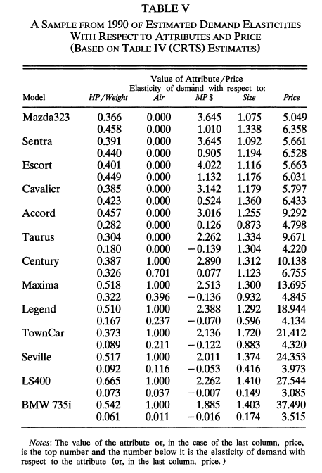

It focuses on a representative sample of specific cars from the year 1990, ranging from cheap compacts (Mazda 323) to luxury sedans (BMW 735i).

For each car, it lists the actual physical attributes and the price on the top row.

# **Table VIII**

The primary purpose of **Table VIII** is to prove that the model respects a fundamental law of microeconomics: **profit margins are driven by price sensitivity**. Since, they assume a Bertrand-Nash oligopoly, the markups should mirror the elasticities of the previous table.

```python
# We compute the implied markups for every car in the dataset
# This relies on the Bertrand-Nash supply-side inversion we estimated
markups = results.compute_markups().flatten()

# We calculate Marginal Costs (MC = Price - Markup)
costs = prod['prices'] - markups

df_econ = prod[['market_ids', 'name', 'prices']].copy()
df_econ['markups'] = markups
df_econ['costs'] = costs

# We isolate the year 1990
df_1990 = df_econ[df_econ['market_ids'] == 1990].reset_index(drop=True)

# We extract the data for these specific cars
table_vi_data = []
for car in target_cars:
    match = df_1990[df_1990['name'].str.contains(car, case=False, na=False)]

    row = match.iloc[0]
    table_vi_data.append({
        'Car Model': car,
        'Price ($)': row['prices'],
        'Marginal Cost ($)': row['costs'],
        'Markup ($)': row['markups']
    })

table_vi = pd.DataFrame(table_vi_data).set_index('Car Model')

table_vi_formatted = (table_vi * 1000).astype(int)

print("="*65)
print("TABLE VIII: ESTIMATED PRICE-MARGINAL COST MARKUPS (1990)")
print("="*65)
print(table_vi_formatted.to_string())
print("="*65)
```

```
=================================================================
TABLE VIII: ESTIMATED PRICE-MARGINAL COST MARKUPS (1990)
=================================================================
           Price ($)  Marginal Cost ($)  Markup ($)
Car Model
323             5048               4903         145
SENT            5661               5498         163
ESCO            5663               5468         195
CAVA            5797               5564         232
ACCO            9292               9050         241
TAUR            9671               9410         260
MAXI           13694              13527         167
SEVI           24353              24055         297
LS40           27543              27299         244
735            37490              37215         275
=================================================================
```

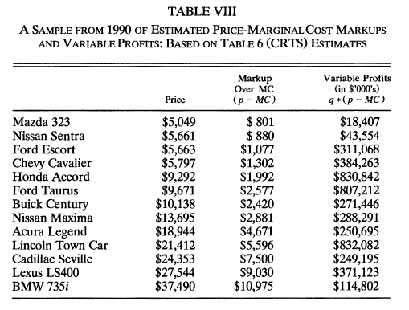